# Amazon US Customer Reviews — Satisfaction Analysis

## 3. Sentiment breakdown — positive, neutral, and negative

Reviews grouped by sentiment: Positive (4–5 stars), Neutral (3 stars), Negative (1–2 stars).

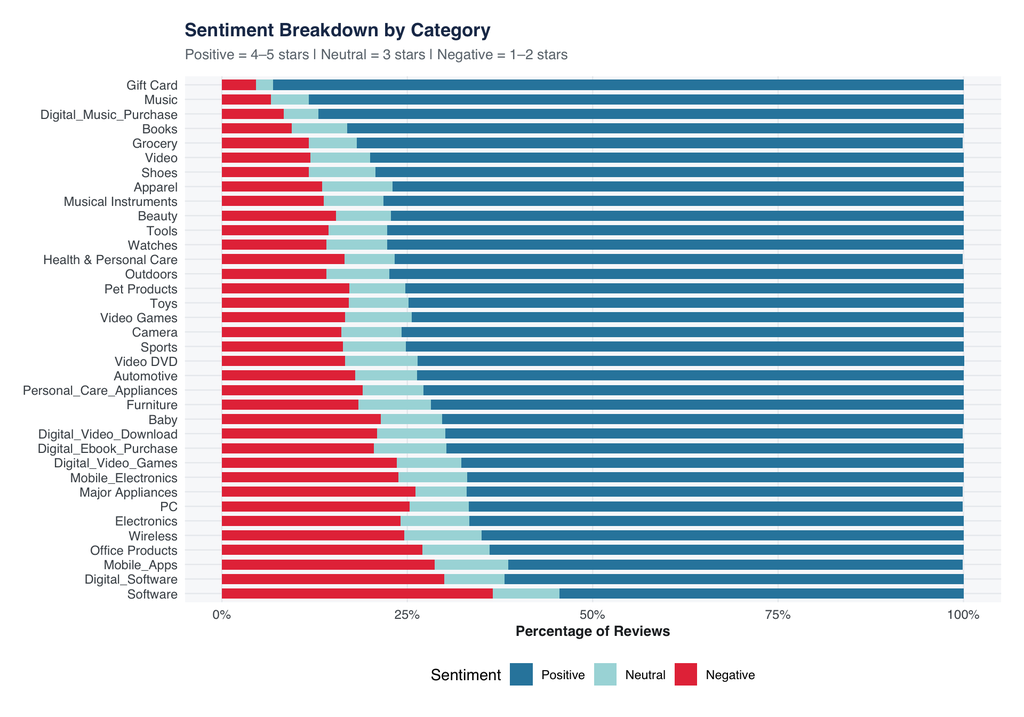

> **Finding:** Most categories are dominated by positive reviews. Software, Digital Software, and Mobile Apps have the highest proportions of negative reviews. Gift Cards are almost entirely positive.

## 4. Are negative reviews found more helpful than positive ones?

Comparing the average percentage of helpful votes received by positive vs negative reviews.

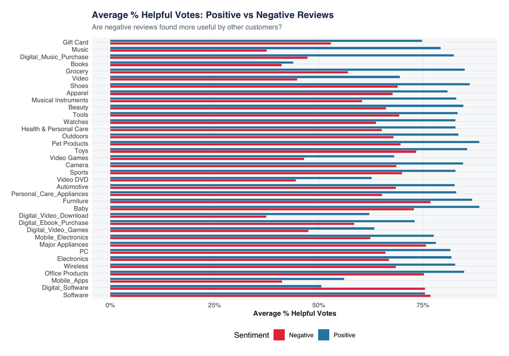

> **Finding:** Across most categories, positive reviews receive a higher percentage of helpful votes than negative reviews. Customers tend to find reviews that match the general satisfaction level more useful, likely because the majority of buyers are satisfied and validate positive experiences.